# Airbnb en Donostia y Euskadi

montera34

March 30, 2017

# Airbnb en Euskadi

La base de datos de Euskadi de InsideAirbnb contiene 2874 alojamientos en 267 municipios, de ellos 395 tienen licencia de alojamiento turístico (13.7%).

En las capitales tenemos:

- **Donostia - San Sebastián** 1219 (42.4 % del total), de esos alojamientos tienen licencia 160 (13.1 % del municipio). Dispone de 4553 plazas. Usuarios con alojamiento listado 696
- **Bilbao** 459 (16.0% del total), de esos alojamientos tienen licencia 74 (16.1 % del municipio). Dispone de 1484 plazas. Usuarios con alojamiento listado 367
- **Vitoria - Gasteiz** 107 (3.7% del total), de esos alojamientos tienen licencia 27 (25.2 % del municipio). Dispone de 361 plazas. Usuarios con alojamiento listado 79

Por comparar con otras ciudades, el porcentaje de alojamientos con licencia turística en Barcelona es 18.0% de un total de 17369 alojamientos según datos de insideairbnb. Madrid (7446 alojamientos) y Mallorca (11271 alojamientos) no tienen indicado si tienen licencia.

## Donostia - San Sebastián

En Donostia existen 696 usuarios con alojamientos disponibles en Airbnb.

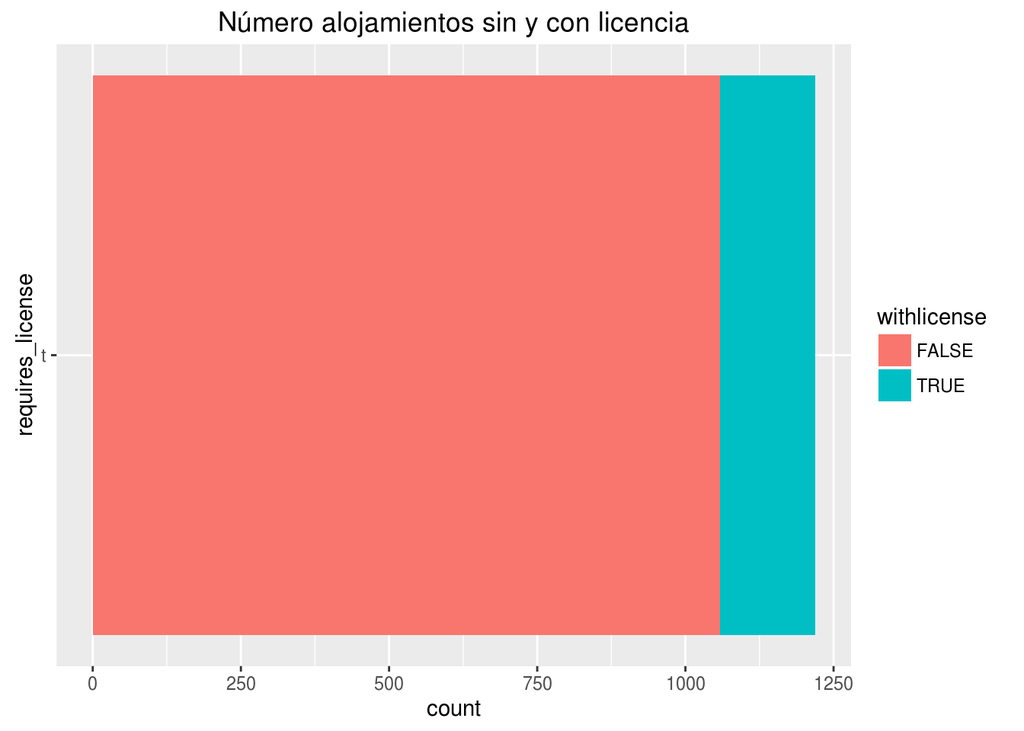

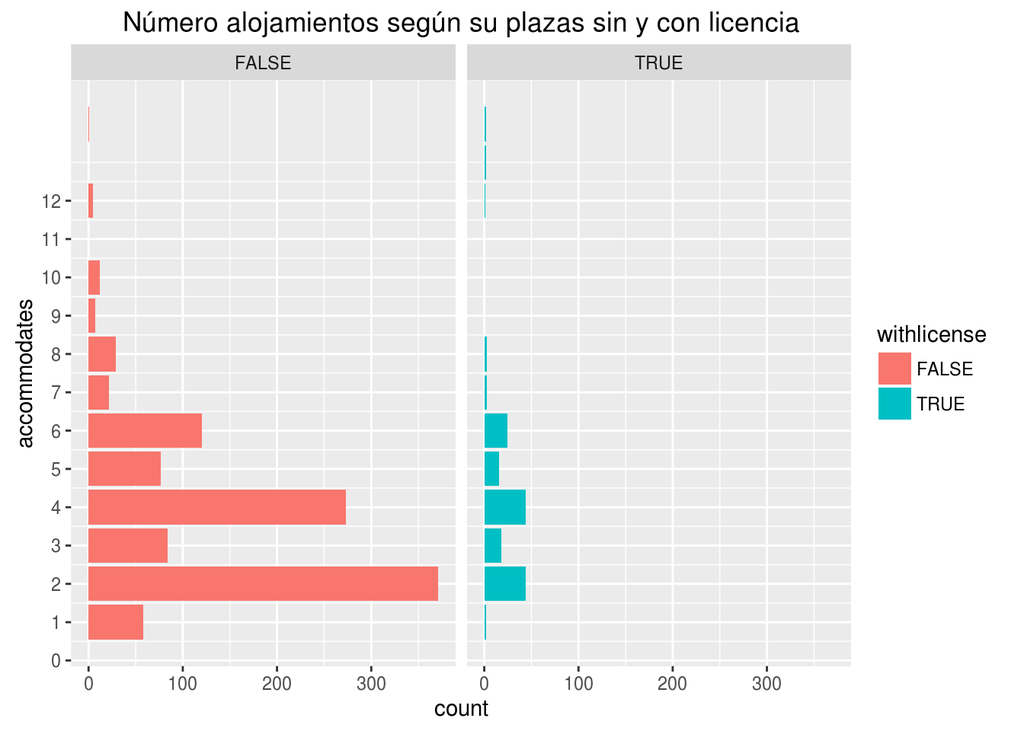

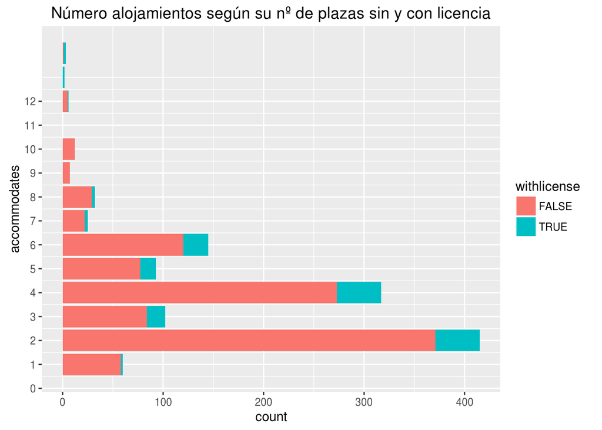

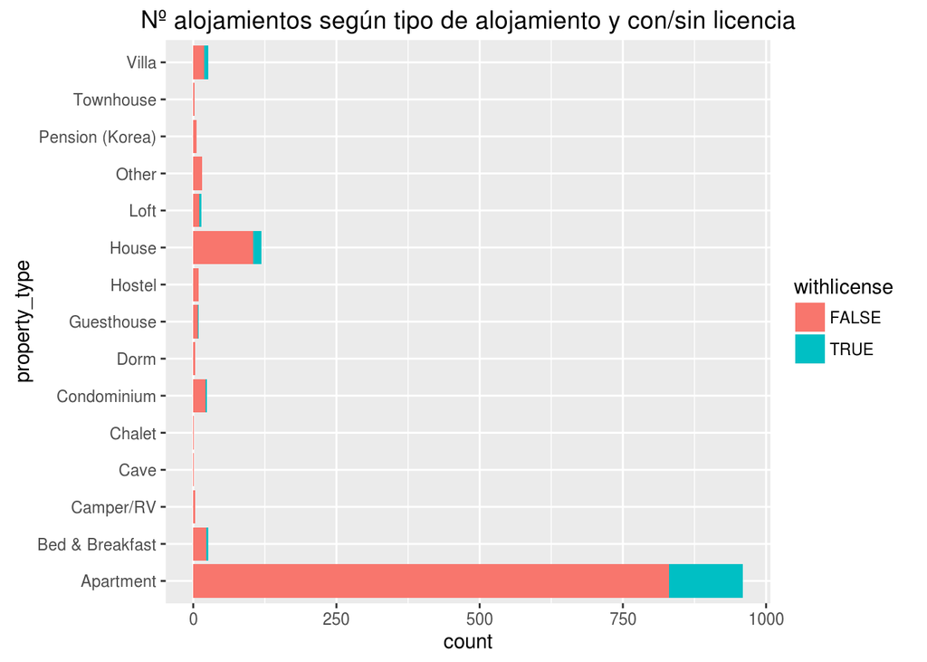

## Usuarios de Airbnb

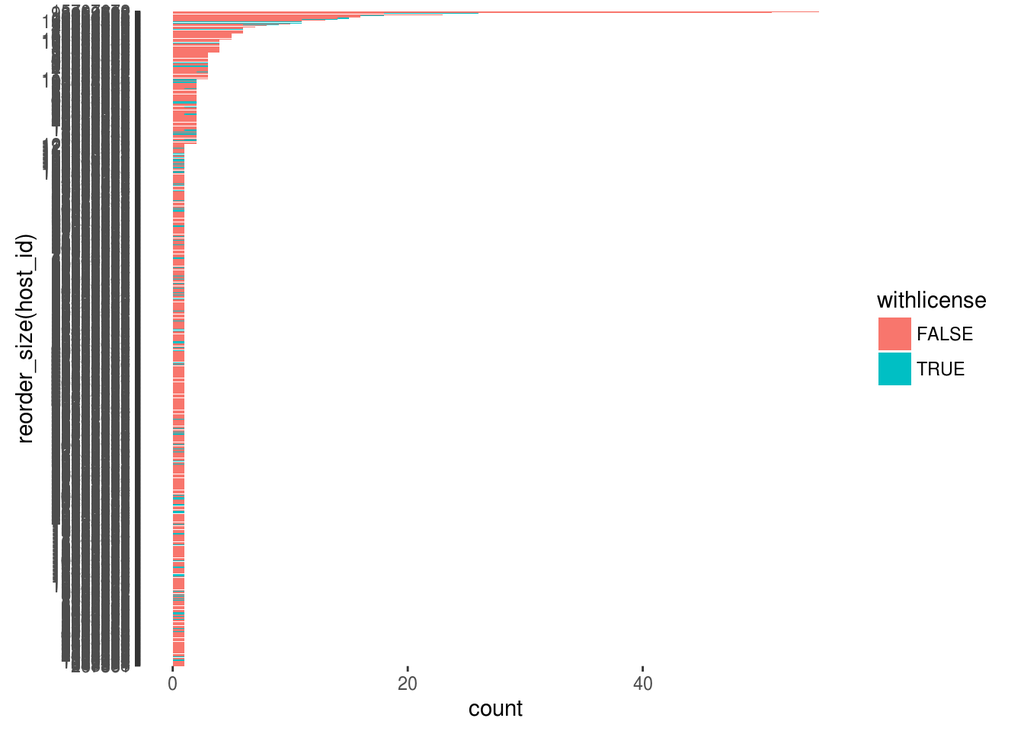

### Los usuarios con más alojamientos

Los 20 usuarios con más alojamientos (id)

| 15707672 | 98419892 | 3952766 | 5254782 | 4614604 | 790667 | 12954077 | 13367653 | 6598471 | 25039584 | 18192487 | 98189424 | 102583389 | 149691 | 50920106 | 2470030 | 73815563 | 2035832 | 2625306 | 5173315 |
| --- | --- | --- | --- | --- | --- | --- | --- | --- | --- | --- | --- | --- | --- | --- | --- | --- | --- | --- | --- |
| 55 | 51 | 26 | 23 | 18 | 16 | 16 | 15 | 14 | 13 | 11 | 11 | 11 | 10 | 9 | 8 | 7 | 6 | 6 | 6 |

### Los usuarios con más plazas

Los **10** primeros usuarios (1.4% del total de usuarios) con más plazas tienen 1119 plazas disponibles (que son el 24.6% del total de plazas).

Los **20** primeros usuarios (2.9% del total de usuarios) con más plazas tienen 1495 plazas disponibles (que son el 32.8% del total de plazas).

Los **50** primeros usuarios (7.2% del total de usuarios) con más plazas tienen 1958 plazas disponibles (que son el 43.0% del total de plazas).

Los **100** primeros usuarios (14.4% del total de usuarios) con más plazas tienen 2392 plazas disponibles (que son el 52.5% del total de plazas).

Los 20 usuarios con más plazas (id)

| host_id | sum.accomodates |
| --- | --- |
| 98419892 | 254 |
| 15707672 | 215 |
| 4614604 | 104 |
| 5254782 | 95 |
| 3952766 | 93 |
| 12954077 | 86 |
| 6598471 | 73 |
| 25039584 | 72 |
| 13367653 | 67 |
| 102583389 | 60 |
| 98189424 | 57 |
| 2470030 | 44 |
| 50920106 | 43 |
| 18192487 | 41 |
| 790667 | 40 |
| 13725999 | 38 |
| 149691 | 29 |
| 10650761 | 28 |
| 63853491 | 28 |
| 109977260 | 28 |

### Precio por noche

[figure not shown]

[figure not shown]

## Otros

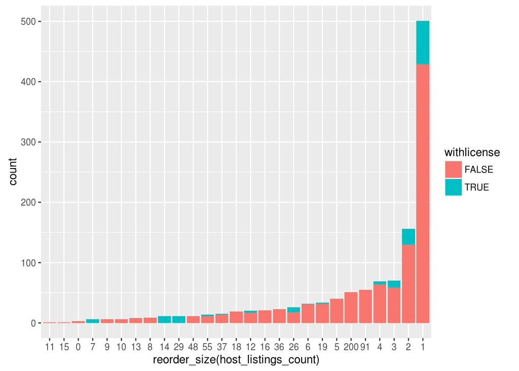

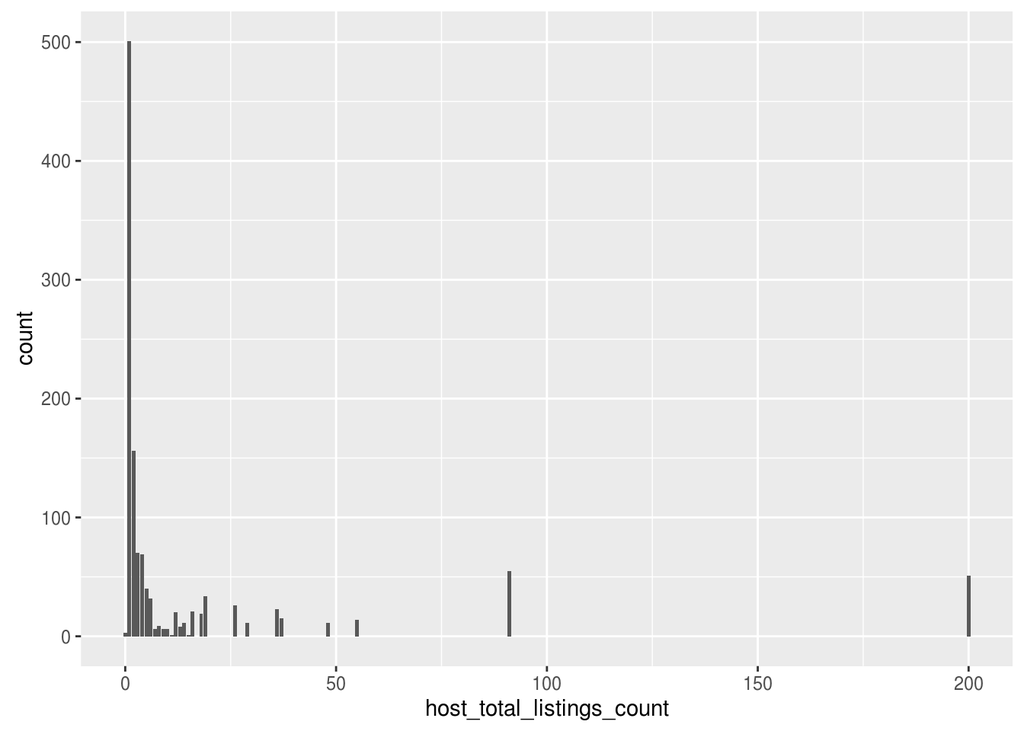

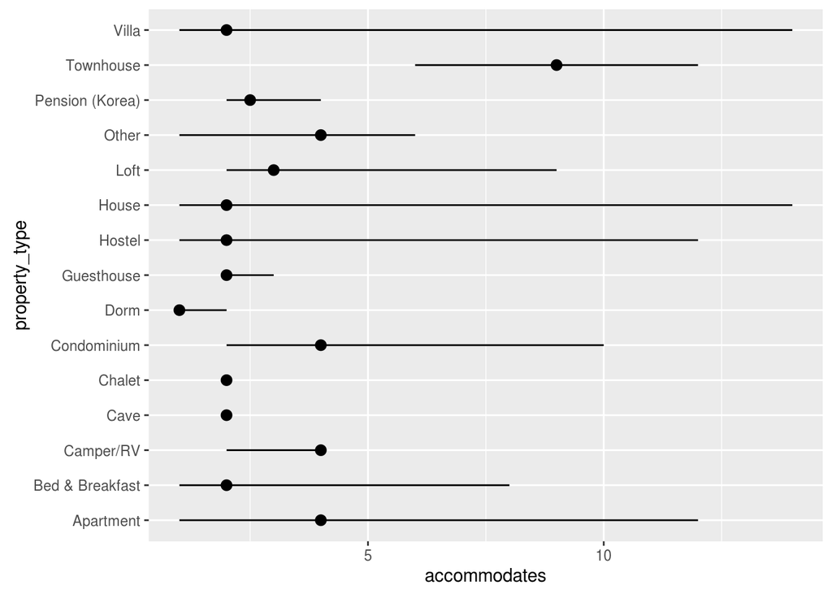

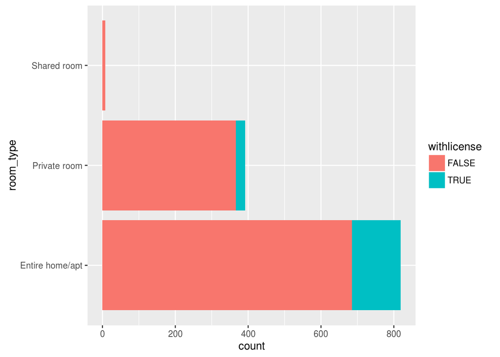

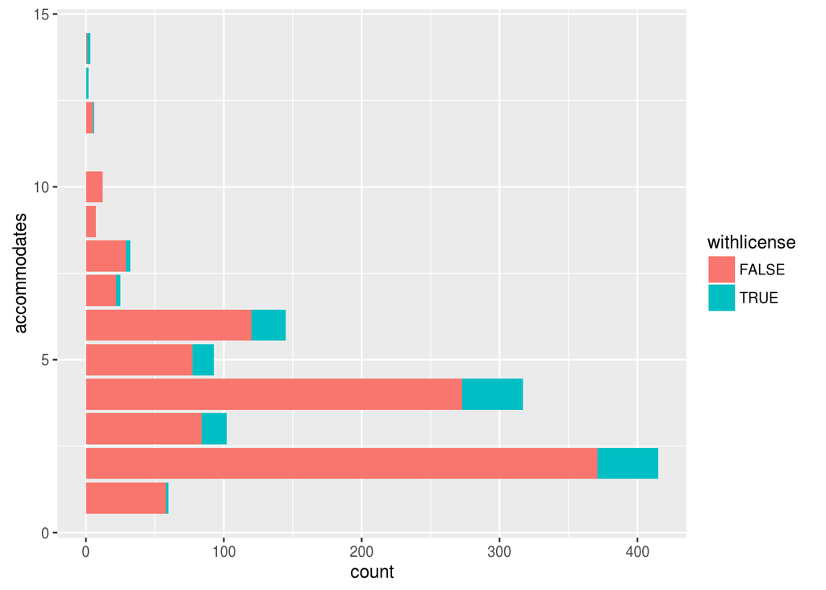

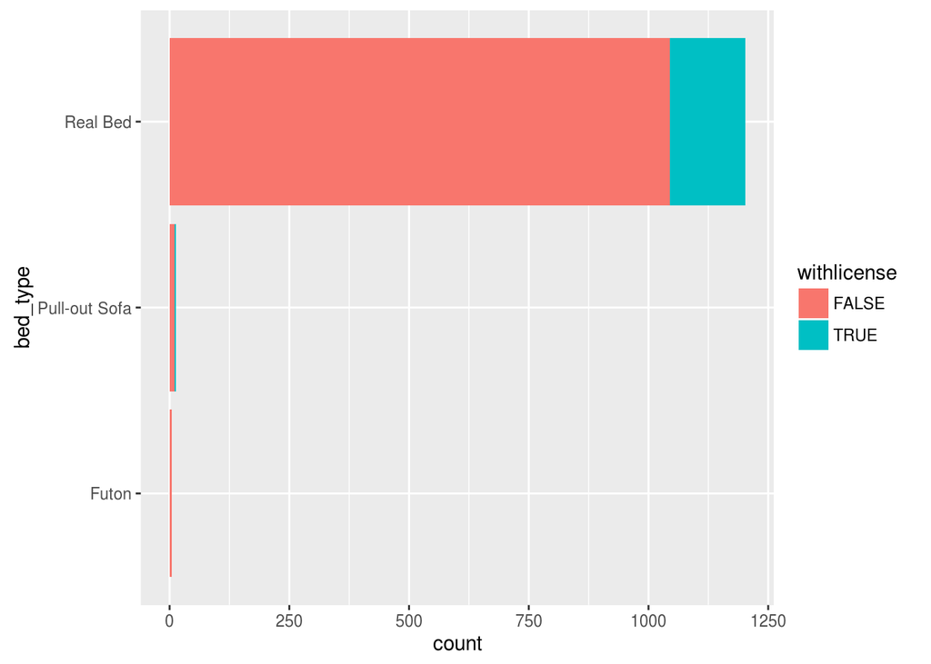

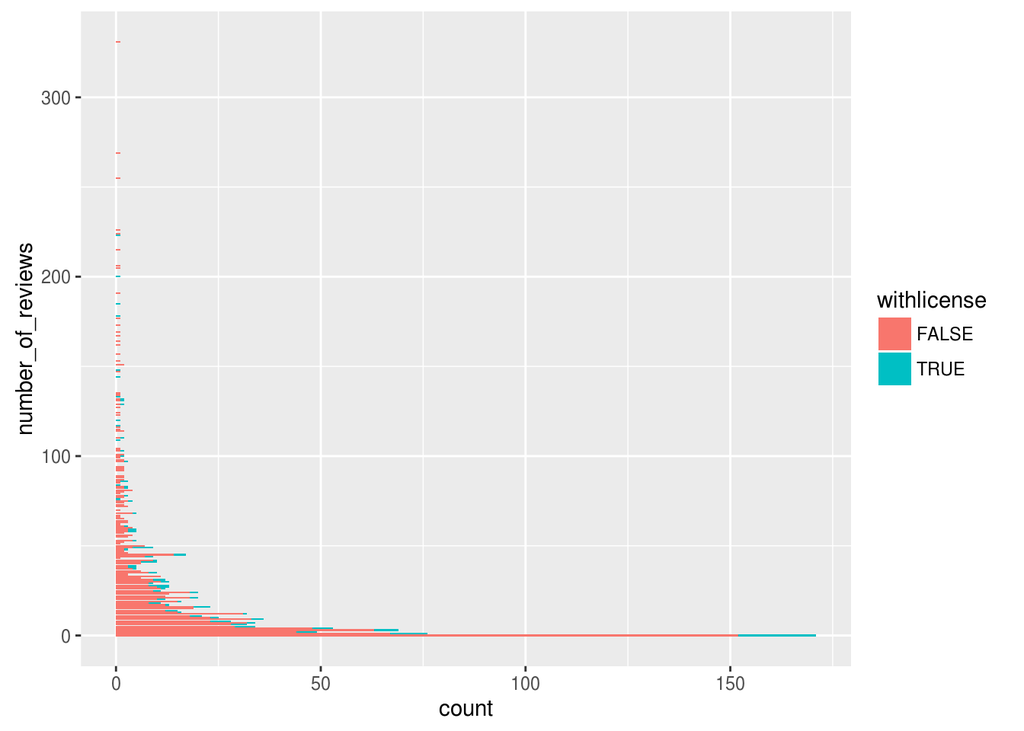

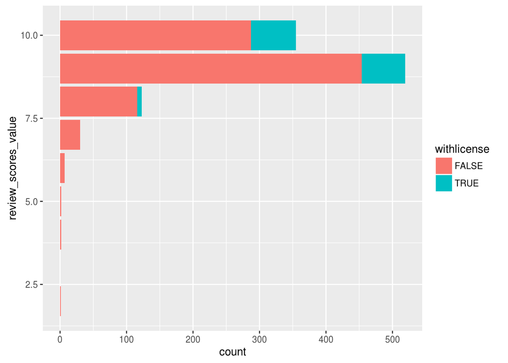

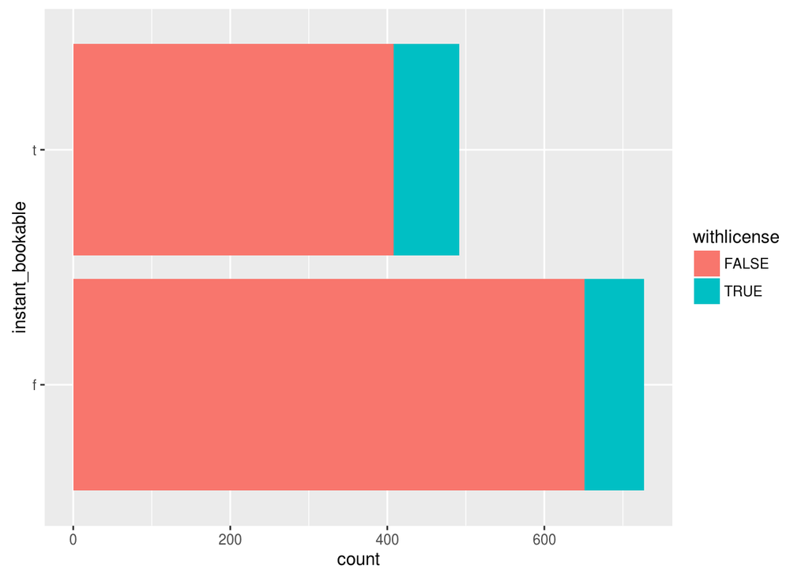

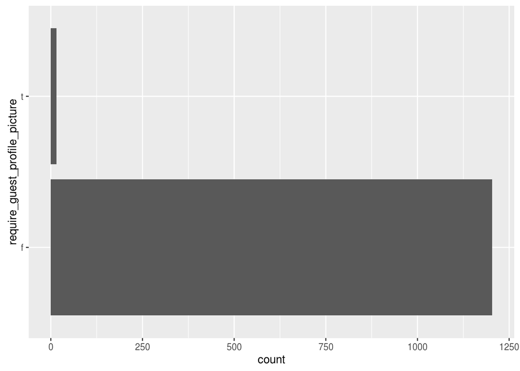

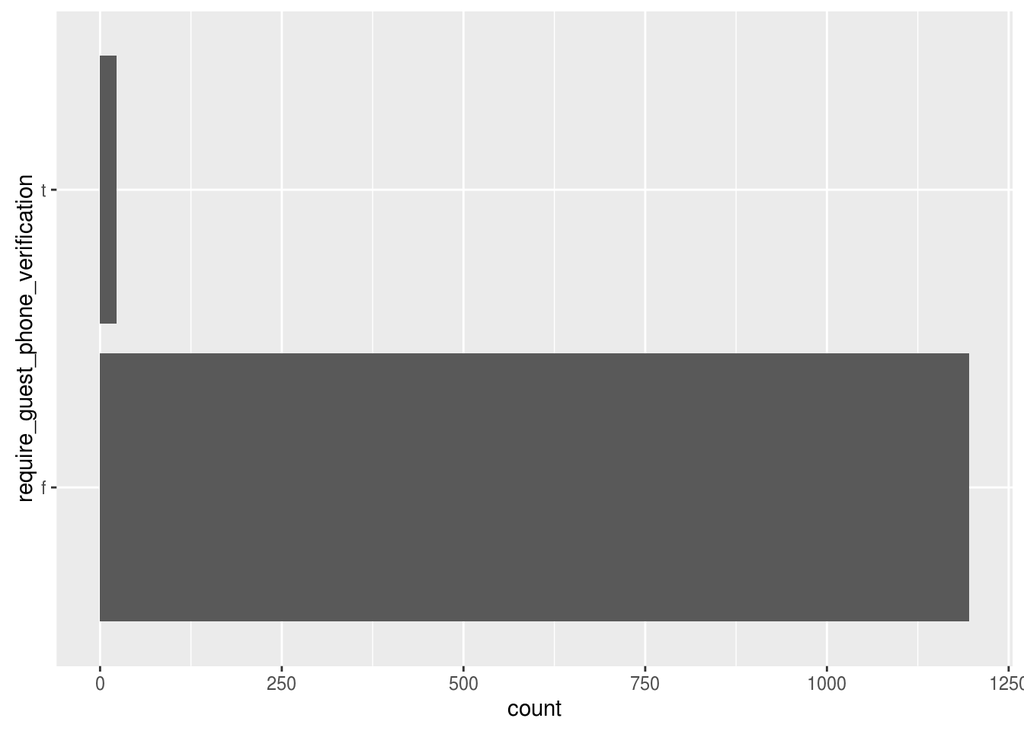

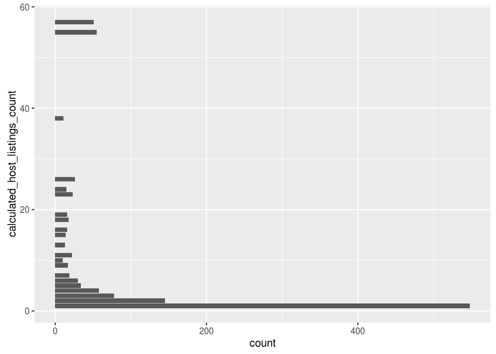

[7 more figures not shown]

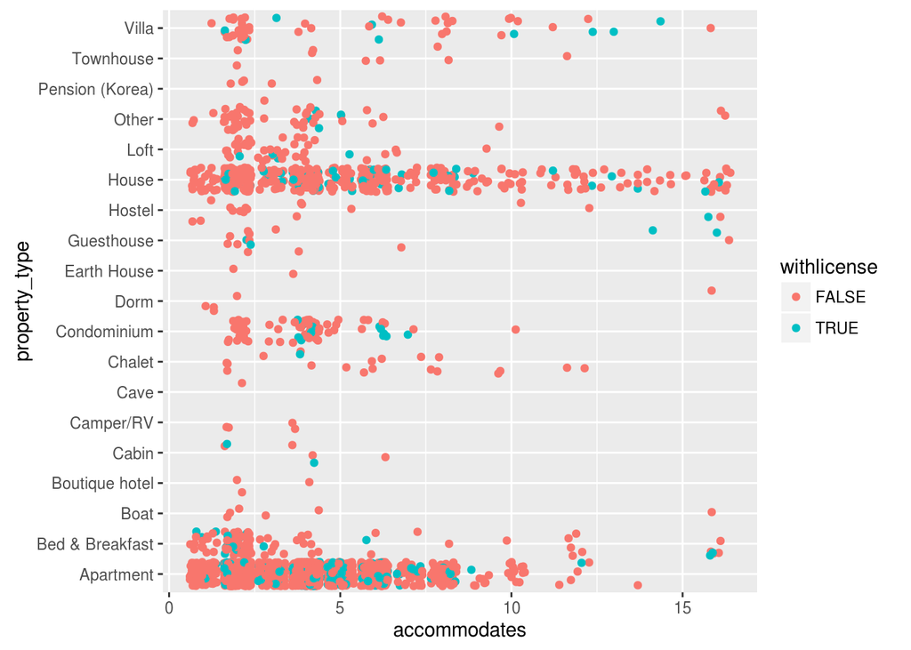

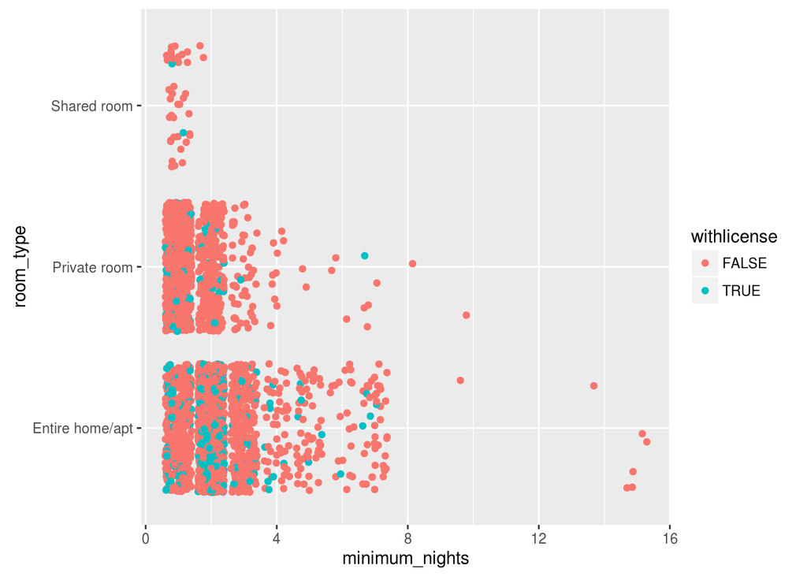

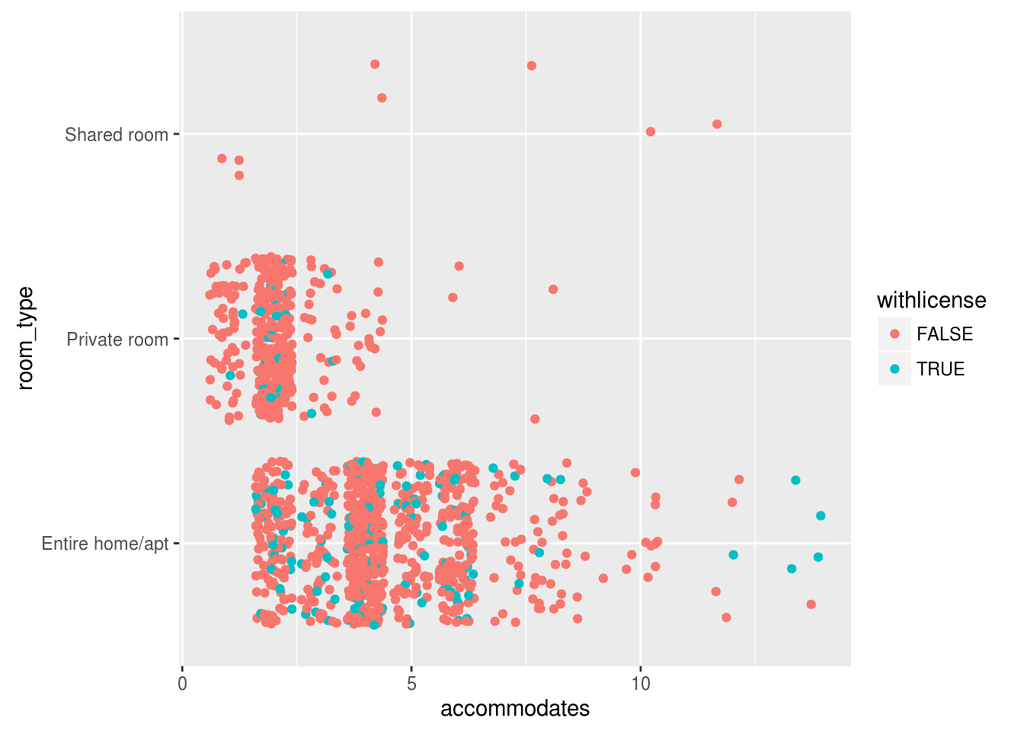